# Tarea 01_Zamora Mennigke_Ricardo

###Programe en R una funcion que genera 200 numeros al azar entre 1 y 500 y luego calcula ###cuantos est´an entre el 50 y 450, ambos inclusive

```r
azar <- runif(200, 1, 500)

numero = 0

for (x in azar) {
  if(x >= 50 & x <= 450){
    numero = numero + 1
  }
}
print(numero)
```

```
## [1] 155
```

##Ejercicio 13

###Desarrolle una funcion que calcula el costo de una llamada telef´onica que ha durado t ###minutos sabiendo que si t < 1 el costo es de 0,4 dolares, mientras que para duraciones ###superiores el costo es de 0,4 + (t − 1)/4 d´olares, la funcion debe recibir el valor de ###t.

```r
costo <- function(t) {
  if(t < 1){
    0.4
  }
  else{
    0.4 + ((t-1)/4)
  }
}
costo(5)
```

```
## [1] 1.4
```

##Ejercicio 14

###Desarrolle una funci´on que recibe una matriz cuadrada A de tama˜no n × n y calcula su ###traza, es decir, la suma de los elementos de la diagonal. Por ejemplo, la traza de la ###siguiente matriz:

```r
A = matrix(c(9, 3, 4, 1, 3, -1, 4, 12, -2), nrow=3, ncol=3, byrow = TRUE)

traza<-function(A){
   sum(diag(A))
}
traza(A)
```

```
## [1] 10
```

##Ejercicio 15

###Escribir una funcion que genere los n primeros terminos de la serie de Fibonacci.

```r
nterms = as.integer(9)
recurse_fibonacci <- function(n) {
if(n <= 1) {
return(n)
} else {
return(recurse_fibonacci(n-1) + recurse_fibonacci(n-2))
}
}
if(nterms <= 0) {
print("Plese enter a positive integer")
} else {
print("Fibonacci sequence:")
for(i in 0:(nterms-1)) {
print(recurse_fibonacci(i))
}
}
```

```
## [1] "Fibonacci sequence:"
## [1] 0
## [1] 1
## [1] 1
## [1] 2
## [1] 3
## [1] 5
## [1] 8
## [1] 13
## [1] 21
```

##Ejercicio 16

###Escriba una funcion que retorne cu´al es el mayor n´umero entero cuyo cuadrado no ###excede de x donde x es un n´umero real que se recibe como par´ametro, utilizando while.

```r
i = 0
cuadrado <- function(x){
  while((i*i) <= x )
    i <- i + 1
  print(i-1)
}
cuadrado(26)
```

```
## [1] 5
```

##Ejercicio 17

###Crear un Data Frame con diez alumnos con su edad, ano de nacimiento y numero de ###telefono. Deber´a aparecer el nombre de la columna (edad, a˜no de nacimiento, telefono) ###y el nombre de la fila, que ser´a el nombre del alumno al que corresponden los datos.

```r
edad = c(7, 5, 3,4,5,6,7,4,5,7)
nacimiento = c(2013, 2015,2017,2016,2015 ,2014,2013,2016,2015,2013)
telefono = c("475885", "6364758", "847578686","09287364","64765758","96867464", "536474", "84746465", "52534748","847464")
dataalumnos = data.frame(row.names = c("e1","e2","e3","e4","e5","e6","e7","e8","e9","e10"), edad, nacimiento, telefono)
dataalumnos
```

```
##     edad nacimiento  telefono
## e1     7       2013    475885
## e2     5       2015   6364758
## e3     3       2017 847578686
## e4     4       2016  09287364
## e5     5       2015  64765758
## e6     6       2014  96867464
## e7     7       2013    536474
## e8     4       2016  84746465
## e9     5       2015  52534748
## e10    7       2013    847464
```

##Ejercicio 18

###Programe funciones en R para calcular

###El numero de permutaciones con repeticion de r objetos tomados de n

```r
library(gtools)
perrepeticion <- function(r,n){
  permutaciones <- permutations(r, n, repeats.allowed=TRUE)
  head(permutaciones)
}
perrepeticion(100, 2)
```

```
##      [,1] [,2]
## [1,]    1    1
## [2,]    1    2
## [3,]    1    3
## [4,]    1    4
## [5,]    1    5
## [6,]    1    6
```

###El numero de permutaciones sin repeticion, o arreglo, de r objetos tomados de n

```r
noperrepeticion <- function(r,n){
  permutaciones <- permutations(r, n, repeats.allowed=FALSE)
  head(permutaciones)
}
noperrepeticion(50, 3)
```

```
##      [,1] [,2] [,3]
## [1,]    1    2    3
## [2,]    1    2    4
## [3,]    1    2    5
## [4,]    1    2    6
## [5,]    1    2    7
## [6,]    1    2    8
```

###El numero de permutaciones con repeticion de n objetos, de los cuales solo k son ###distintos.

```r
perrepeticionk <- function(r,n){
  permutaciones <- permutations(r, n, repeats.allowed=TRUE)
  head(permutaciones)
}
perrepeticionk(50, 4)
```

```
##      [,1] [,2] [,3] [,4]
## [1,]    1    1    1    1
## [2,]    1    1    1    2
## [3,]    1    1    1    3
## [4,]    1    1    1    4
## [5,]    1    1    1    5
## [6,]    1    1    1    6
```

###El numero de combinaciones es un subconjunto desordenado de r objetos seleccionados ###en un conjunto que contiene n.

```r
comrepeticion <- function(r,n){
  combinaciones <- combinations(r, n, repeats.allowed=FALSE)
  head(combinaciones)
}
comrepeticion(100, 3)
```

```
##      [,1] [,2] [,3]
## [1,]    1    2    3
## [2,]    1    2    4
## [3,]    1    2    5
## [4,]    1    2    6
## [5,]    1    2    7
## [6,]    1    2    8
```

###El n´umero de combinaciones con repeticion es un subconjunto desordenado de r objetos ###seleccionados de un conjunto que contiene n en los cuales se pueden repetir.

```r
library(copula)
```

```r
stir2 <- function(n,k){
  stir <- Stirling2(n, k)
  head(stir)
}
stir2(50, 3)
```

```
## [1] 1.196497e+23
```

##Ejercicio 19

###. Desarrolle una funci´on R que recibe un DataFrame que retorna la cantidad de entradas ###de este DataFrame que son divisibles entre 3.

```r
divisor <- function(x, tol = .Machine$double.eps^0.5) abs(x - round(x)) < tol

divi3 <- function(DF) {
    n <- dim(DF)[1]
    m <- dim(DF)[2]
    div <- 0
    for (i in 1:n) {
        for (j in 1:m) {
            num1 <- DF[i, j]/3
            if (divisor(num1) == "TRUE") {
                div <- div + 1
            }
        }
    }
    return(div)
}

datosdiv <- matrix(c(7, 9, 18, 1, 3, 5, 27, 12, 8,10), 5, 2)
divi3(datosdiv)
```

```
## [1] 5
```

##Ejercicio 20

###Desarrolle una funci´on R que recibe un DataFrame y dos n´umeros de columna y que ###retorna en una lista el nombre de las variables correspondientes a las columnas, la ###covarianza y la correlacion entre esas dos variables.

```r
edad = c(7, 5, 3,4,5,6,7,4,5,7)
nacimiento = c(2013, 2015,2017,2016,2015 ,2014,2013,2016,2015,2013)
telefono = c(475885, 6364758, 847578686,09287364,64765758,96867464, 536474, 84746465, 52534748,84746)
dataalumnos = data.frame(row.names = c("e1","e2","e3","e4","e5","e6","e7","e8","e9","e10"), edad, nacimiento, telefono)

variables<-function(dataalumnos,col1,col2){
  if((ncol(dataalumnos)>=col1) & (ncol(dataalumnos)>=col2)){
  c(dataalumnos[col1],dataalumnos[col2],cov(dataalumnos[col1],dataalumnos[col2]),
    cor(dataalumnos[col1],dataalumnos[col2]))
  }else{
    "error"
  }
}

variables(dataalumnos,2,3)
```

```
## $nacimiento
##  [1] 2013 2015 2017 2016 2015 2014 2013 2016 2015 2013
##
## $telefono
##  [1]    475885   6364758 847578686   9287364  64765758  96867464    536474
##  [8]  84746465  52534748     84746
##
## [[3]]
## [1] 226566915
##
## [[4]]
## [1] 0.6153247
```

##Ejercicio 21

###Importe directamente desde Excel en R el archivo EjemploAlgoritmosRecomendacion.xlsx el ##cual contiene los promedios de evaluaci´on de 100 personas que adquirieron los mismos ###productos o muy similares en la tienda AMAZON. Luego ejecute un str(…) y un ###summary(…) con esta tabla de datos.

```r
library(xlsx)
```

[output not shown]

```r
datos3 <- read.table("EjemploAlgoritmosRecomendacion.csv", header=TRUE, sep=";", dec=",", row.names=1)
str(datos3)
```

```
## 'data.frame':    100 obs. of  9 variables:
##  $ VelocidadEntrega: num  2.05 0.9 1.7 1.35 3 0.95 2.3 0.65 2.75 2 ...
##  $ Precio          : num  0.3 1.5 2.6 0.5 0.45 1.65 1.2 2.1 0.8 1.75 ...
##  $ Durabilidad     : num  3.45 3.15 2.85 3.55 4.8 3.95 4.75 3.1 4.7 3.25 ...
##  $ ImagenProducto  : num  2.35 3.3 3 2.95 3.9 2.4 3.3 2.55 2.35 3 ...
##  $ ValorEducativo  : num  2.4 2.5 4.3 1.8 3.4 2.6 3.5 2.8 3.5 3.7 ...
##  $ ServicioRetorno : num  2.3 4 2.7 2.3 4.6 1.9 4.5 2.2 3 3.2 ...
##  $ TamanoPaquete   : num  2.6 4.2 4.1 3.9 2.25 4.85 3.8 3.45 3.8 4.35 ...
##  $ Calidad.Producto: num  2.1 2.15 2.6 1.95 3.4 2.2 2.9 2.15 2.7 2.7 ...
##  $ NumeroEstrellas : num  1.7 2.8 3.3 1.7 4.3 3 3.1 2.9 4.8 3.9 ...
```

```r
summary(datos3)
```

```
##  VelocidadEntrega     Precio        Durabilidad    ImagenProducto
##  Min.   :0.000    Min.   :0.1000   Min.   :2.500   Min.   :1.250
##  1st Qu.:1.250    1st Qu.:0.7375   1st Qu.:3.350   1st Qu.:2.288
##  Median :1.700    Median :1.0750   Median :4.025   Median :2.500
##  Mean   :1.758    Mean   :1.1820   Mean   :3.947   Mean   :2.624
##  3rd Qu.:2.300    3rd Qu.:1.6125   3rd Qu.:4.550   3rd Qu.:3.000
##  Max.   :3.050    Max.   :2.7000   Max.   :5.000   Max.   :4.100
##  ValorEducativo  ServicioRetorno TamanoPaquete   Calidad.Producto
##  Min.   :0.700   Min.   :1.100   Min.   :1.850   Min.   :1.600
##  1st Qu.:2.400   1st Qu.:2.200   1st Qu.:2.900   1st Qu.:2.050
##  Median :3.000   Median :2.600   Median :3.575   Median :2.425
##  Mean   :2.916   Mean   :2.665   Mean   :3.486   Mean   :2.385
##  3rd Qu.:3.425   3rd Qu.:3.000   3rd Qu.:4.162   3rd Qu.:2.700
##  Max.   :4.600   Max.   :4.600   Max.   :5.000   Max.   :3.400
##  NumeroEstrellas
##  Min.   :1.000
##  1st Qu.:2.400
##  Median :3.150
##  Mean   :3.110
##  3rd Qu.:3.825
##  Max.   :5.000
```

##Ejercicio 22

###Programe la siguiente funcion recursiva:

```r
recursiva <- function(n) {
    if (n == 0) {
        return(5)
    } else {
        if (n == 1) {
            return(-5)
        } else {
            if (n == 2) {
                return(2)
            } else {
                if (n >= 3) {
                  return((4 * recursiva(n-1)) - (15 * recursiva(n-2)) + (recursiva(n-3)))
                }
            }
        }
    }
}

recursiva(6)
```

```
## [1] -4867
```

##Ejercicio 23

###Programe la siguiente funci´on f(x) = x n de forma recursiva.

```r
xn <- function(x,n) {
   if(n == 0) {
     return(1)
   }
   else {
     return(x*xn(x,n-1))
   }
}

xn(5,2)
```

```
## [1] 25
```

##Ejercicio 24

###El archivo bosques energia.csv el cual contiene el resultado de dos estudios, uno en el ###que se mide la superficie boscosa en proporci´on al terreno total de cada pa´ıs y el ###otro corresponde al consumo de energ´ıa renovable en proporci´on al consumo de energ´ıa ###total. Estos estudios se hicieron en varios pa´ıses y en varios a˜nos distintos. Con ###estos datos realize lo siguiente:

```r
library(dplyr)
library(tidyr)
library(readxl)
library(tidyverse)
```

###Convierta los datos a datos tidy.

```r
bosques <- read.table("bosques_energia.csv", header=TRUE,sep=",")
head(bosques)
```

```
##          Pais Codigo.Pais
## 1       Aruba         ABW
## 2       Aruba         ABW
## 3 Afghanistan         AFG
## 4 Afghanistan         AFG
## 5      Angola         AGO
## 6      Angola         AGO
##                                                             Indicador X1960
## 1                  Superficie forestal (% de la superficie terrestre)    NA
## 2 Consumo de energía renovable (% del consumo total de energía final)    NA
## 3                  Superficie forestal (% de la superficie terrestre)    NA
## 4 Consumo de energía renovable (% del consumo total de energía final)    NA
## 5                  Superficie forestal (% de la superficie terrestre)    NA
## 6 Consumo de energía renovable (% del consumo total de energía final)    NA
##   X1961 X1962 X1963 X1964 X1965 X1966 X1967 X1968 X1969 X1970 X1971 X1972 X1973
```

[output cut: 48 more lines]

```r
bosques1 <- data.frame(bosques)
bosques_tidy <- gather(data = bosques1, Pais, Codigo.Pais, -Indicador)
head(bosques_tidy)
```

```
##                                                             Indicador Pais
## 1                  Superficie forestal (% de la superficie terrestre) Pais
## 2 Consumo de energía renovable (% del consumo total de energía final) Pais
## 3                  Superficie forestal (% de la superficie terrestre) Pais
## 4 Consumo de energía renovable (% del consumo total de energía final) Pais
## 5                  Superficie forestal (% de la superficie terrestre) Pais
## 6 Consumo de energía renovable (% del consumo total de energía final) Pais
##   Codigo.Pais
## 1       Aruba
## 2       Aruba
## 3 Afghanistan
## 4 Afghanistan
## 5      Angola
## 6      Angola
```

###Elimine las variables innecesarias y explique el motivo

```r
bosques_long <- gather(data = bosques1, Pais, Codigo.Pais, -Indicador, X1960:X2018, na.rm = TRUE)
head(bosques_long)
```

```
##                                                             Indicador Pais
## 1                  Superficie forestal (% de la superficie terrestre) Pais
## 2 Consumo de energía renovable (% del consumo total de energía final) Pais
## 3                  Superficie forestal (% de la superficie terrestre) Pais
## 4 Consumo de energía renovable (% del consumo total de energía final) Pais
## 5                  Superficie forestal (% de la superficie terrestre) Pais
## 6 Consumo de energía renovable (% del consumo total de energía final) Pais
##   Codigo.Pais
## 1       Aruba
## 2       Aruba
## 3 Afghanistan
## 4 Afghanistan
## 5      Angola
## 6      Angola
```

```r
#Los datos estan almacenados para cada ano en varias columnas, aqui se debe denotar que el almacenamiento no es limpio, pero bastante util para analisis posteriores. Debe apilarse estos datos. De esta forma se deben apilar los anos para que correspondan a una unica columna de lectura.
```

###Con la ayuda del paquete dplyr, realice lo siguiente:

```r
library(dplyr)
```

```r
bosques2 <- pivot_longer(bosques, cols = X1960:X2018, names_to = "year", values_to = "valor")

head(bosques2)
```

```
## # A tibble: 6 x 6
##   Pais  Codigo.Pais Indicador                                  X     year  valor
##   <fct> <fct>       <fct>                                      <lgl> <chr> <dbl>
## 1 Aruba ABW         Superficie forestal (% de la superficie t~ NA    X1960    NA
## 2 Aruba ABW         Superficie forestal (% de la superficie t~ NA    X1961    NA
## 3 Aruba ABW         Superficie forestal (% de la superficie t~ NA    X1962    NA
## 4 Aruba ABW         Superficie forestal (% de la superficie t~ NA    X1963    NA
## 5 Aruba ABW         Superficie forestal (% de la superficie t~ NA    X1964    NA
## 6 Aruba ABW         Superficie forestal (% de la superficie t~ NA    X1965    NA
```

```r
library(ggplot2)
res <- Pais %>% filter(Codigo.Pais %in% c("CAN", "CHN", "PER", "PRY")) %>%
  group_by(Codigo.Pais, year) %>% summarise(total.valor = sum(valor))
```

```
## Error in eval(lhs, parent, parent): object 'Pais' not found
```

```r
ggplot(res, aes(x = "year", y = "valor")) + geom_line(aes(color = blues9))
```

```
## Error in ggplot(res, aes(x = "year", y = "valor")): object 'res' not found
```

```r
library(ggplot2)
res <- Pais %>% filter(Codigo.Pais %in% top_n(bosques, 10, Indicador)) %>%
  group_by(Codigo.Pais, year) %>% summarise(total.valor = sum(valor))
```

```
## Error in eval(lhs, parent, parent): object 'Pais' not found
```

```r
ggplot(res, aes(x = "year", y = "valor")) + geom_line(aes(color = blues9))
```

```
## Error in ggplot(res, aes(x = "year", y = "valor")): object 'res' not found
```

##Ejercicio 25

###El archivo DatosEducacion.csv contiene informaci´on de las escuales primarias de varios ###pa´ıses durante los a˜nos 2013 a 2019. Las variables est´an por filas, los valores de ###dichas variables est´an ###en forma columna por a˜no.

###Convierta el dataset a uno tidy. Elimine las variables innecesarias y los valores con ###NA.

```r
edu <- read.table("DatosEducacion.csv", header=TRUE,sep=",")
head(edu)
```

```
##                                    indicador iso3 pais fecha  valor
## 57348 Cantidad de Estudiantes que repitieron  TGO Togo  2013 253214
## 57349 Cantidad de Estudiantes que repitieron  TGO Togo  2014 158276
## 57350 Cantidad de Estudiantes que repitieron  TGO Togo  2015 132214
## 57351 Cantidad de Estudiantes que repitieron  TGO Togo  2016 118488
## 57352 Cantidad de Estudiantes que repitieron  TGO Togo  2017 117760
## 57353 Cantidad de Estudiantes que repitieron  TGO Togo  2018 117099
```

```r
edu1 <- data.frame(edu)
edu_tidy <- gather(data = edu, Indicador, iso3, pais, fecha, valor,na.rm=T)
head(edu_tidy)
```

```
##                                indicador Indicador iso3
## 1 Cantidad de Estudiantes que repitieron      pais Togo
## 2 Cantidad de Estudiantes que repitieron      pais Togo
## 3 Cantidad de Estudiantes que repitieron      pais Togo
## 4 Cantidad de Estudiantes que repitieron      pais Togo
## 5 Cantidad de Estudiantes que repitieron      pais Togo
## 6 Cantidad de Estudiantes que repitieron      pais Togo
```

###Agrupe el dataset por pa´ıs y promedie los resultados, no incluya la variable fecha. ###Adem´as, cambie los nombres de las variables a unos m´as ‘cortos’.

```r
res <- group_by(edu_tidy, iso3)
res <- summarise(res, total.casos = mean(valor))
```

```
## Error in mean(valor): object 'valor' not found
```

###Ejecute una Agrupaci´on Jer´arquica con 3 clusters y muestre el dendrograma formado.

```r
modelo <- hclust(dist(edu1),method = "single" )
```

[figure not shown]

```r
plot(modelo)
rect.hclust(modelo, k=3, border="blue")
```

[figure not shown]

```r
modelo <- hclust(dist(Datos),method = "average")
plot(modelo)
rect.hclust(modelo, k=3, border="green")
```

###Calcule los centros de cada cluster y d´e una interpretaci´on usando el gr´afico de tipo ###radar.

```r
summary(modelo)
```

```
##             Length Class  Mode
## merge       198    -none- numeric
## height       99    -none- numeric
## order       100    -none- numeric
## labels      100    -none- character
## method        1    -none- character
## call          3    -none- call
## dist.method   1    -none- character
```

[figure not shown]

```r
df.rad = expand.grid(letters[1:10], 1:5)
df.rad$score = runif(nrow(df.rad))
ggplot(df.rad, aes(x = Var1, y = score, col = Var2, group = Var2)) + geom_point() + geom_line() + coord_polar()
```

```r
#Lo que se denota aqui es existe un cluster que acumula pocas variables por lo que es probable que se necesiten mas clusters.
```

###Construya una variable con el porcentaje de estudiantes que repiteron el a˜no y otra con ###el gasto p´ublico bruto si se repartiera en partes iguales a cada estudiante. Luego ###elimine las variables que se utilizaron para crear las 2 variables anteriores. Por ###ultimo, repita los 2 ejercicios anteriores con estos nuevos datos.

```r
summary(modelo)
```

```
##             Length Class  Mode
## merge       198    -none- numeric
## height       99    -none- numeric
## order       100    -none- numeric
## labels      100    -none- character
## method        1    -none- character
## call          3    -none- call
## dist.method   1    -none- character
```

```r
edu1 <- data.frame(edu)
edu_tidy <- gather(data = edu, Indicador, iso3, pais, fecha, valor,na.rm=T)
head(edu_tidy)
```

```
##                                indicador Indicador iso3
## 1 Cantidad de Estudiantes que repitieron      pais Togo
## 2 Cantidad de Estudiantes que repitieron      pais Togo
## 3 Cantidad de Estudiantes que repitieron      pais Togo
## 4 Cantidad de Estudiantes que repitieron      pais Togo
## 5 Cantidad de Estudiantes que repitieron      pais Togo
## 6 Cantidad de Estudiantes que repitieron      pais Togo
```

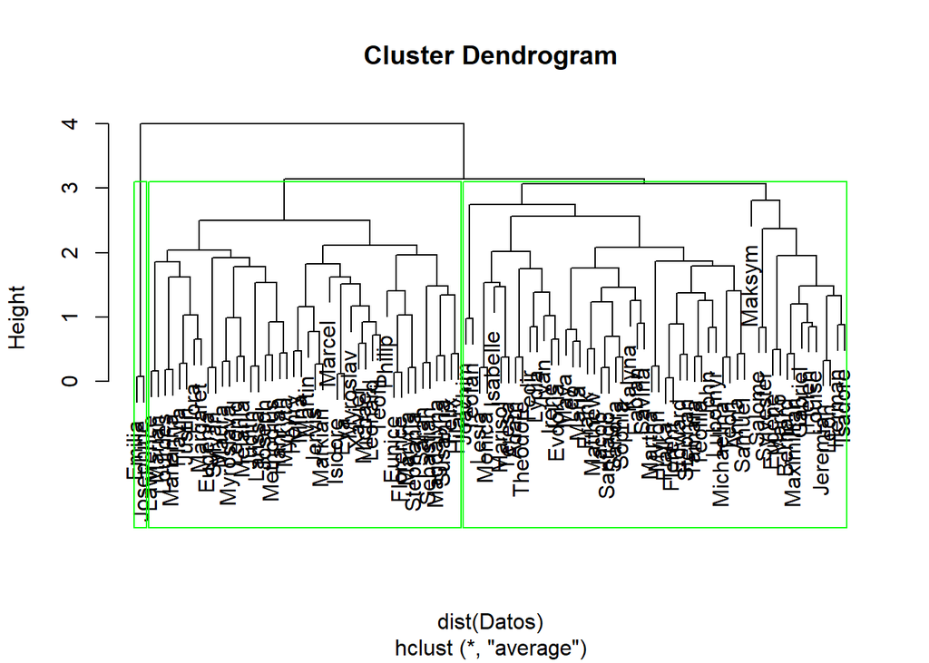

```r
modelo <- hclust(dist(Datos),method = "average")
plot(modelo)
rect.hclust(modelo, k=3, border="green")
```

[figure not shown]

```r
df.rad = expand.grid(letters[1:10], 1:5)
df.rad$score = runif(nrow(df.rad))
ggplot(df.rad, aes(x = Var1, y = score, col = Var2, group = Var2)) + geom_point() + geom_line() + coord_polar()
```

```r
#Lo que se denota aqui es existe un cluster que acumula pocas variables por lo que es probable que se necesiten mas clusters.
```

###De los 2 resultados obtenidos anteriormente, ¿Cu´al le hace m´as sentido, seg´un los ###pa´ıses agrupados y sus caracter´ısticas?

###¿A que se debe que sean tan diferentes los 2 resultados obtenidos?